# Environmental_data_vignette

```r
# Install packages for installing other packages
if (!require("devtools", quietly = TRUE)) install.packages("devtools")
if (!require("BiocManager", quietly = TRUE)) install.packages("BiocManager")

# For environmental and geographic data processing:
if (!require("RStoolbox", quietly = TRUE))devtools::install_github("bleutner/RStoolbox")
if (!require("geodata", quietly = TRUE)) install.packages("geodata")
if (!require("corrplot", quietly = TRUE)) install.packages("corrplot")
if (!require("vegan", quietly = TRUE)) install.packages("vegan")
if (!require("gdistance", quietly = TRUE)) install.packages("gdistance")
if (!require("topoDistance", quietly = TRUE)) install.packages("topoDistance")
if (!require("rmapshaper", quietly = TRUE)) install.packages("rmapshaper")
if (!require("wingen", quietly = TRUE)) devtools::github_install("wingen")
```

# Processing environmental data for landscape genomics

```r
library(algatr)
library(terra)
library(raster)
library(RStoolbox)
library(ggplot2)
library(geodata)
library(viridis)
library(wingen)
library(tidyr)
library(tibble)
```

For landscape genomic analyses, environmental data layers must be processed in several ways before they can be used as input into methods. This vignette will explore several ways to process environmental data:

- `get_worldclim()` to pull environmental layers remotely from the WorldClim database
- Detect collinearity:
  - `check_env()` to detect collinearity between environmental layers
  - `check_vals()` to detect collinearity between extracted environmental values
  - `check_dists()` to detect collinearity between geographic and environmental distances
- `rasterPCA()` to perform a raster PCA on a stack of environmental layers to reduce dimensionality
- `coords_to_raster()` to create a raster layer from coordinate data (using the wingen package)
- `env_dist()` to calculate environmental distances
- `geo_dist()` to calculate geographic distances between coordinates

### Load example data

```r
load_algatr_example()
```

```
#>
#> ---------------- example dataset ----------------
#>
#> Objects loaded:
#> *liz_vcf* vcfR object (1000 loci x 53 samples)
#> *liz_gendist* genetic distance matrix (Plink Distance)
#> *liz_coords* dataframe with x and y coordinates
#> *CA_env* RasterStack with PC environmental layers
#>
#> -------------------------------------------------
#>
#>
```

## Introduction to environmental data files and object types

Briefly, in R, any (geo)spatial data can be represented using points, vectors, or rasters. Points represent coordinates. Vectors are used for discrete phenomena that have clear boundaries (e.g., a country), while rasters are used to represent continuous data (e.g., precipitation). Rasters are able to represent continuous data by dividing up the landscape into a grid of equally sized cells; each cell is then assigned one (or more) values for relevant variables. In our case, taking California as an example, points represent sampling coordinates, vectors represent polygons (e.g., the state of California), and rasters store different environmental layers (e.g. temperature, precipitation) for California.

There are two main packages algatr uses to process and manipulate environmental data: terra ([Hijmans 2022](https://cran.r-project.org/web/packages/terra/index.html)) and raster ([Hijmans 2022](https://cran.r-project.org/web/packages/raster/index.html)). Both of these packages have excellent resources and walkthroughs (see [here](https://rspatial.org/terra/) for terra; see [here](https://rspatial.org/raster/pkg/index.html) for raster) that explain in depth environmental data processing and manipulation in R.

Each of these packages has their own classes to represent rasters. Within the terra package, the `SpatRaster` class is used to represent rasters, while the raster package uses `RasterLayer` (single-layer raster data), `RasterBrick` and `RasterStack` (both are multi-variable raster data but differ in how many files can be linked to them) classes. No matter which class is used to represent rasters, the fundamental parameters that describe these rasters are always the same: numbers of rows, columns, the spatial extent, and the coordinate reference system (CRS) for proper projection.

Ensuring that the CRS between your coordinates and raster layer is particularly important. For all of algatr’s methods, if no CRS is provided, a warning will be generated but the respective method will run assuming that the coordinates and raster CRS match; if the CRS between these two inputs do not match, algatr will throw an error. Also keep in mind that some methods cannot be performed with non-projected data (such as kriging), so users must always transform their coordinates if they’re in lat/long, for example. Refer to the wingen vignette ([here](https://github.com/AnushaPB/wingen/blob/main/vignettes/wingen-vignette.Rmd)) for further information how to convert lat/long coordinates to a projected system.

## Gather environmental data using `get_worldclim()`

Users can add a buffer around sampling coordinates using the `buff` argument, which corresponds to the proportion of the spatial extent for the coordinates. Tile size (i.e., spatial resolution) is specified using the `res` argument, which corresponds to arc-minutes. The default is the 30s dataset (0.5 arc-mins), with a buffer of 0.01.

Because `get_worldclim` can take some time, the following code will not knit within the vignette but will give you an idea of how to run the function with the example data.

```r
wclim <- get_worldclim(coords = liz_coords, res = 5) # can set save_output = TRUE if you want a directory with files made
```

```r
# Load wclim object
data("wclim")
# Look at one of the layers, which corresponds to tile_15_wc2.1_30s_bio_1
wclim[[1]]
```

```
#> class      : RasterLayer
#> dimensions : 113, 120, 13560  (nrow, ncol, ncell)
#> resolution : 0.08333333, 0.08333333  (x, y)
#> extent     : -125.25, -115.25, 32.58333, 42  (xmin, xmax, ymin, ymax)
#> crs        : +proj=longlat +datum=WGS84 +no_defs
#> source     : memory
#> names      : bio1
#> values     : -1.311542, 24.08433  (min, max)
```

Now, let’s plot one of the variables and overlay our sampling coordinates on top.

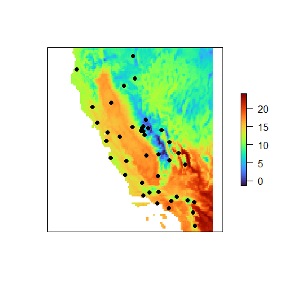

```r
plot(wclim[[1]], col = turbo(100), axes = FALSE)
points(liz_coords, pch = 19)
```

## Detecting collinearity

An important first check for any landscape genomics analysis is to detect collinearity between sets of variables. Specifically, we always want to verify that there is no collinearity (within a given threshold) between environmental layers (using `check_env()`), extracted values from environmental layers (using `check_vals()`), and geographic and environmental distances (using `check_dists()`) as many of the methods used for landscape genomics assume that these variables are independent.

### Collinearity among environmental layers

The `check_env()` function calculates the Pearson correlation coefficient for pairwise comparisons of environmental layers. The `threshold` is the correlation coefficient; it defaults to 0.7. The output from this function is a list containing (1) a dataframe of correlated environmental pairs that fall above the threshold, and (2) a correlation matrix with all pairwise correlation coefficients.

```r
cors_env <- check_env(wclim)
```

```r
# There are many pairs of layers that have correlation coefficients > 0.7 (the default threshold)
```

[output not shown]

```r
# For the sake of argument, we can also run this function on the CA_env object:
check_env(CA_env)
```

```
#> $cor_df
#> [1] var1 var2 r
#> <0 rows> (or 0-length row.names)
#>
#> $cor_matrix
#>              CA_rPCA1     CA_rPCA2     CA_rPCA3
#> CA_rPCA1 1.000000e+00 2.367727e-11 4.231118e-11
#> CA_rPCA2 2.367727e-11 1.000000e+00 3.888803e-11
#> CA_rPCA3 4.231118e-11 3.888803e-11 1.000000e+00
```

```r
# None of the pairwise comparisons exceed the threshold value
```

### Collinearity among extracted environmental values

Similar to the above, the `check_vals()` function determines collinearity using Pearson’s correlation coefficients, but it does so on extracted environmental variables at each of the sampling coordinates. This will also generate a plot showing the pairwise correlations between environmental variables.

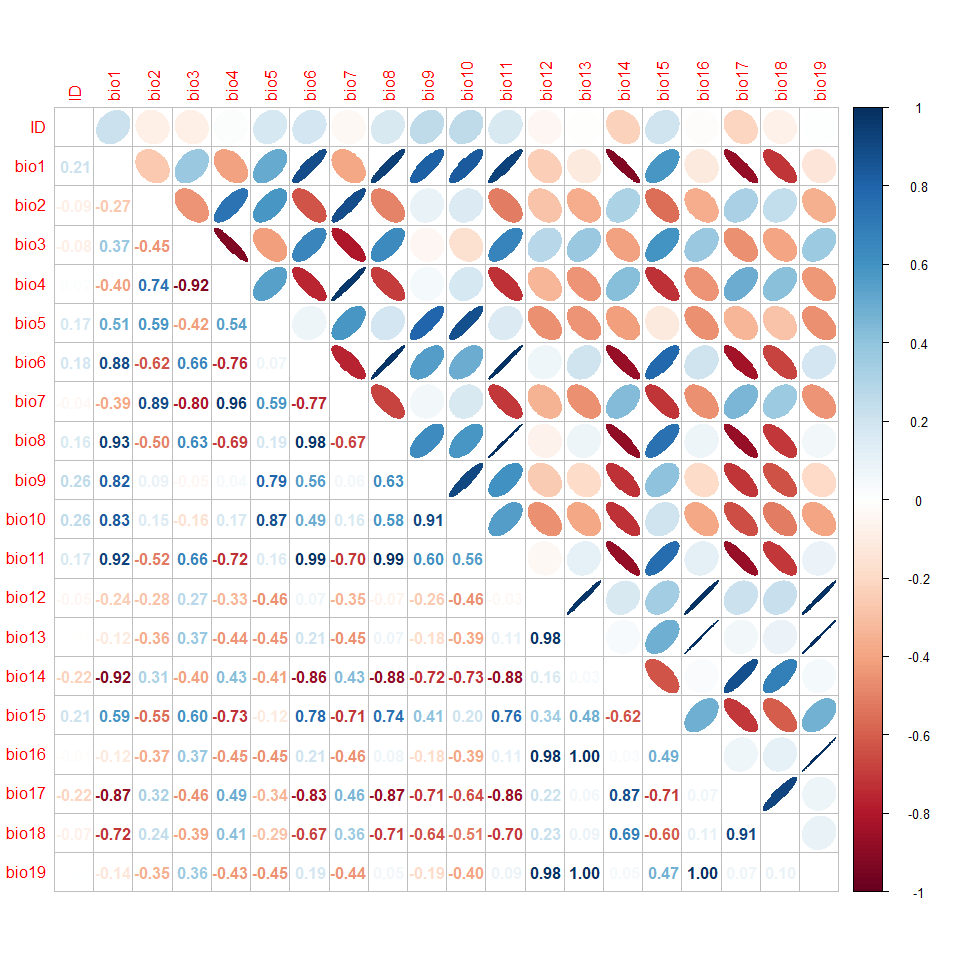

```r
# Once again, we can see that there are many pairs of variables that exceed the threshold
check_result <- check_vals(wclim, liz_coords)
```

```r
head(check_result$cor_df)
```

```
#>   var1 var2         r
#> 1 bio2 bio4 0.7363230
#> 2 bio1 bio6 0.8829763
#> 3 bio2 bio7 0.8851769
#> 4 bio4 bio7 0.9640441
#> 5 bio1 bio8 0.9317171
#> 6 bio6 bio8 0.9761442
```

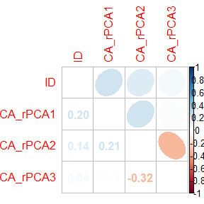

```
#> $cor_df
#> [1] var1 var2 r
#> <0 rows> (or 0-length row.names)
#>
#> $cor_matrix
#>                  ID   CA_rPCA1   CA_rPCA2    CA_rPCA3
#> ID       1.00000000 0.20306375  0.1439392  0.04309331
#> CA_rPCA1 0.20306375 1.00000000  0.2095724  0.01194543
#> CA_rPCA2 0.14393920 0.20957242  1.0000000 -0.32015438
#> CA_rPCA3 0.04309331 0.01194543 -0.3201544  1.00000000
```

```r
# Check using the CA_env object; note that these values are quite different from those from check_env()
check_vals(CA_env, liz_coords)
```

### Collinearity between distances

The `check_dists()` function determines collinearity between geographic and environmental distances. It does so by extracting values at sampling coordinates, and then calculating geographic and environmental distances and runs a Mantel test on resulting distances. Environmental distances are calculated using Euclidean distances, while geographic distances can be Euclidean, topographic, or resistance distances, though the default is Euclidean. The result of this function is to output the p-value and Mantel’s r and indicate which distances are significantly correlated.

```r
check_results <- check_dists(wclim, liz_coords)
head(check_results$mantel_df)
```

```
#>   var1 var2    p          r
#> 1  geo bio2 0.02 0.14655852
#> 2 bio2 bio3 0.01 0.36879426
#> 3  geo bio4 0.01 0.16604751
#> 4   ID bio4 0.04 0.07768818
#> 5 bio2 bio4 0.01 0.57247312
#> 6 bio3 bio4 0.01 0.84170158
```

```r
# We can see that PC2 from CA_env and geo dists are significantly correlated!
check_dists(CA_env, liz_coords)
```

[output not shown]

## Perform a raster PCA on environmental layers

Because of collinearity issues, and because we may not want to deal with dozens of environmental layers at a time, we can perform a PCA on our rasters using the `rasterPCA()` function in the [RStoolbox package](https://cran.r-project.org/web/packages/RStoolbox/index.html); this function can take in a `SpatRaster` or `RasterStack` object. Let’s use the `wclim` object we generated above using the `get_worldclim()` function, which contains 19 environmental variables. The result of this function is a list containing the model information, and a RasterBrick object containing multiple layers of PCA scores. One can also use the `nComp` argument to only extract the top n PCs; in many cases, the top three PCs may explain the majority of the variance of the data, and so only those will be considered for further analyses.

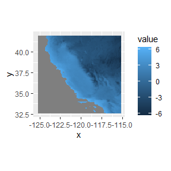

```r
env_pcs <- rasterPCA(wclim, spca = TRUE)

# Let's take a look at the results for the top three PCs
plots <- lapply(1:3, function(x) ggR(env_pcs$map, x, geom_raster = TRUE))

plots[[1]]
```

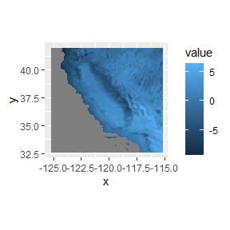

```r
plots[[2]]
```

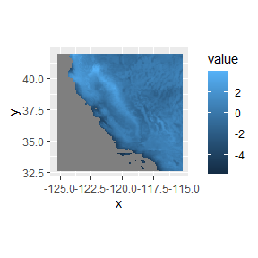

```r
plots[[3]]
```

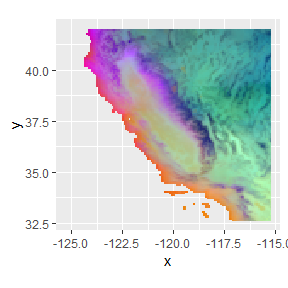

```r
# We can also create a single composite raster plot with 3 PCs (each is assigned R, G, or B)
ggRGB(env_pcs$map, 1, 2, 3, stretch = "lin", q = 0)
```

## Create raster from coordinates with wingen: `coords_to_raster()`

In some cases, we may not have a raster already prepared. Using the wingen package, we can use our coordinate data to generate a raster given a user-specified buffer around sampling coordinates (using the `buff` argument) and with a given resolution (using the `res` argument). This raster does not have any meaningful values assigned to it, but can be used to create maps of genetic diversity in wingen (see the wingen documentation [here](https://github.com/AnushaPB/wingen)).

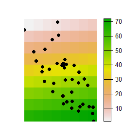

```r
raster <- coords_to_raster(liz_coords, res = 1)
plot(raster, axes = FALSE)
points(liz_coords, pch = 19)
```

## Calculate environmental distances using `env_dist()`

Some of the analyses within algatr, such as GDM and MMRR, require comparing genetic distances to environmental distances. We can calculate environmental distances using the `env_dist()` function, which allows users to calculate environmental distances between variables for given sampling locations. We first need to extract environmental variables at sampling coordinates.

```r
env <- raster::extract(CA_env, liz_coords)

# You can there are extracted values (n=53) for each environmental layer
head(env)
```

```
#>       CA_rPCA1   CA_rPCA2    CA_rPCA3
#> [1,] -1.851397 -3.9385712 -0.71366495
#> [2,] -2.288577 -0.7470118 -0.05549845
#> [3,] -4.294456  4.4240017 -1.50788176
#> [4,] -1.916433 -3.7858098 -1.37762737
#> [5,] -1.942174  0.2111327  1.20659840
#> [6,] -2.463599  4.4038172 -2.02557206
```

Now, we’re ready to calculate environmental distances.

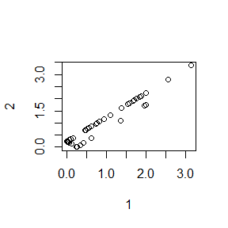

```r
env_dist <- env_dist(env)
plot(env_dist$CA_rPCA1)
```

We can make a heat map in ggplot with the pairwise distances.

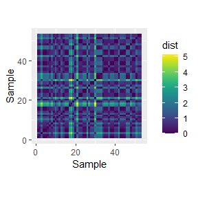

```r
as.data.frame(env_dist$CA_rPCA1) %>%
  rownames_to_column("sample") %>%
  pivot_longer(-"sample", names_to = "sample_comp", values_to = "dist") %>%
  ggplot(aes(x = as.numeric(sample), y = as.numeric(sample_comp), fill = dist)) +
  geom_tile() +
  coord_equal() +
  scale_fill_viridis() +
  xlab("Sample") +
  ylab("Sample")
```

## Calculate geographic distances using `geo_dist()`

- Geodesic distances (`"euclidean"` or `"linear"`) using the geodist package ([Padgham & Sumner 2021](https://CRAN.R-project.org/package=geodist))
- Topographic distances (`"topo"` or `"topographic"`) using the topoDistance package ([Wang 2020](https://besjournals.onlinelibrary.wiley.com/doi/full/10.1111/2041-210X.13317)); requires a digital elevation model (DEM) raster specified with the `lyr` argument
- Resistance distances (`"resistance"`, `"cost"`, or `"res"`) using the gdistance package ([van Etten 2017](https://www.jstatsoft.org/article/view/v076i13)); requires a resistance raster specified with the `lyr` argument

### Euclidean distances

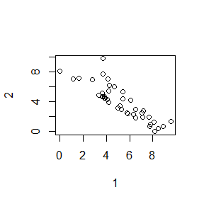

```r
geo_dist <- geo_dist(liz_coords, type = "Euclidean")
plot(geo_dist)
```

We can make a heat map in ggplot with the pairwise distances.

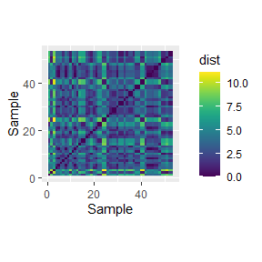

```r
# Make a fun heat map with the pairwise distances
geo_dist <- as.data.frame(geo_dist)
colnames(geo_dist) <- rownames(geo_dist)
geo_dist %>%
  rownames_to_column("sample") %>%
  gather("sample_comp", "dist", -"sample") %>%
  ggplot(aes(x = as.numeric(sample), y = as.numeric(sample_comp), fill = dist)) +
  geom_tile() +
  coord_equal() +
  scale_fill_viridis() +
  xlab("Sample") +
  ylab("Sample")
```

### Topographic distances

We can also calculate topographic distances, but need to provide a digital elevation model (DEM) raster to do so. We can retrieve a DEM using the geodata package, cropping to California using the `CA_env` object in our example dataset.

```r
# Download the DEM raster using the elevation_30s function
# This will save a .tif file in your current dir
dem <- elevation_30s(country = "USA", path = getwd())

# Crop to California limits
CA_dem <- crop(dem, CA_env)
```

Take a look at what the DEM looks like, with samples plotted on top.

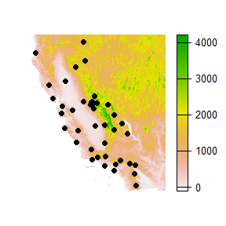

```r
plot(CA_dem, axes = FALSE)
points(liz_coords, pch = 19)
```

Now, let’s calculate topographic distances using the `CA_dem` object as our layer with the `lyr` argument.

```r
topo_dist <- geo_dist(liz_coords, type = "topo", lyr = CA_dem)
```

```
#> Calculating topo distances... This can be time consuming with many points and large rasters.
```

Plot the resulting topographic distances as a heatmap.

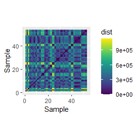

```r
# Make a fun heat map with the pairwise distances
topo_dist <- as.data.frame(topo_dist)
colnames(topo_dist) <- 1:53
rownames(topo_dist) <- 1:53

topo_dist %>%
  rownames_to_column("sample") %>%
  gather("sample_comp", "dist", -"sample") %>%
  ggplot(aes(x = as.numeric(sample), y = as.numeric(sample_comp), fill = dist)) +
  geom_tile() +
  coord_equal() +
  scale_fill_viridis() +
  xlab("Sample") +
  ylab("Sample")
```

## Additional documentation and citations

|  | Citation/URL | Details |
| --- | --- | --- |
| Associated code | terra ([Hijmans 2022](https://cran.r-project.org/web/packages/terra/index.html)) and raster ([Hijmans 2022](https://cran.r-project.org/web/packages/raster/index.html)) | algatr largely uses terra and raster packages to process and manipulate environmental data |
| Associated documentation | Walkthroughs for terra [here](https://rspatial.org/terra/) and raster [here](https://rspatial.org/raster/pkg/index.html) |  |
| Associated code | [Padgham & Sumner 2021](https://CRAN.R-project.org/package=geodist) | algatr uses the geodist package to calculate Euclidean distances |
| Associated code | [Wang 2020](https://besjournals.onlinelibrary.wiley.com/doi/full/10.1111/2041-210X.13317) | algatr uses the topoDistance package to calculate topographic distances |
| Associated code | [van Etten 2017](https://www.jstatsoft.org/article/view/v076i13); vignette available [here](http://127.0.0.1:20697/library/gdistance/doc/Overview.html) | algatr uses the gdistance package to calculate resistance distances |

Retrieve relevant vignettes:

```r
vignette("topoDistance-vignette")
vignette("geodist")
```